# BuenoMattera-CS544-Term-Project

Franco Bueno Mattera

11/24/2020

## Project Description:

The main objective of this project is to analyze a dataset that contains information about different data analysts positions around the United States. There are 3 main questions that this project intends to answer:

1. As of July 2020, what is the general distribution of the variable Salary for data analysts’ jobs?
2. As of July 2020, what is the most common type of company that offers data analyst positions across the United States?
3. As of July 2020, what is the variability and distribution of salaries between the cities of New, York, Chicago, Los Angeles, Charlotte (NC), San Francisco and Austin (TX)?

## 1. Data Preparation and Preprocessing:

```r
#### Opening the Dataset:

df <- read.csv('DataAnalyst.csv')
summary(df)
```

```
##        X         Job.Title         Salary.Estimate        Rating
##  Min.   :   0   Length:2253        Length:2253        Min.   :-1.000
##  1st Qu.: 563   Class :character   Class :character   1st Qu.: 3.100
##  Median :1126   Mode  :character   Mode  :character   Median : 3.600
##  Mean   :1126                                         Mean   : 3.161
##  3rd Qu.:1689                                         3rd Qu.: 4.000
##  Max.   :2252                                         Max.   : 5.000
##  Company.Name         Location         Headquarters           Size
##  Length:2253        Length:2253        Length:2253        Length:2253
##  Class :character   Class :character   Class :character   Class :character
##  Mode  :character   Mode  :character   Mode  :character   Mode  :character
##
##
##
##     Founded     Type.of.ownership    Industry            Sector
##  Min.   :  -1   Length:2253        Length:2253        Length:2253
##  1st Qu.:  -1   Class :character   Class :character   Class :character
##  Median :1979   Mode  :character   Mode  :character   Mode  :character
##  Mean   :1399
##  3rd Qu.:2002
##  Max.   :2019
##    Revenue          Competitors         Easy.Apply
##  Length:2253        Length:2253        Length:2253
##  Class :character   Class :character   Class :character
##  Mode  :character   Mode  :character   Mode  :character
##
##
##
```

```r
sprintf("This dataset, in its original form contains %d rows and %d columns",
        nrow(df), ncol(df))
```

```
## [1] "This dataset, in its original form contains 2253 rows and 15 columns"
```

## 1.1 Cleaning the dataset in order to address the questions from project:

```r
# Deleting some unnecessary columns:
df <- df[,-c(14, 15)]

# deleting rows labels ad -1 (those are missing values that are labeled like
# that in order to work with ML problems)

df[df == -1] <- NA
df <- na.omit(df)
```

## 1.2 Preparing the dataset to answer questions of interest:

```r
# Selecting main columns:
df <- df[,c(3,6, 10)]
summary(df)
```

```
##  Salary.Estimate      Location         Type.of.ownership
##  Length:1559        Length:1559        Length:1559
##  Class :character   Class :character   Class :character
##  Mode  :character   Mode  :character   Mode  :character
```

```r
sprintf("This dataset now clean of NAs contains %d rows and %d columns",
        nrow(df), ncol(df))
```

```
## [1] "This dataset now clean of NAs contains 1559 rows and 3 columns"
```

### 1.2.1 Creating two numeric columns that contain minimum and maximum

salary estimates:

```r
library(readr)
library(tidyr)
#split columns by '-'

df <- separate(df, Salary.Estimate, c('min.salary', 'max.salary'), sep = '-')
df$min.salary <- as.numeric(parse_number(as.character(df$min.salary)))
df$max.salary <- as.numeric(parse_number(as.character(df$max.salary)))

# Source: https://stackoverflow.com/questions/14543627/extracting-numbers-from-vectors-of-strings
# https://tidyr.tidyverse.org/reference/separate.html
unique(df$min.salary)
```

```
##  [1]  37  46  51  59  43  60  41  45  73  84  27  42  77  98  48  26  31  47  49
## [20]  30  55  57  35  65 113  67  97  68  29  74  53  38  64  50  76  34  24  44
## [39] 110  89  69  58  63  40  28  54  99  93  82  32  36  78
```

```r
unique(df$max.salary)
```

```
##  [1]  66  87  88  85  76 110  78 127  90  52  74 132 114  96  47  59  81  69 112
## [20]  54 103  70  45  82  92 129  38 123  94 102  68  44 113  93  89 122 124  61
## [39]  48  53  86 190 151 116 104  42  77  72  67  75  99 178 159 120 101  56  91
## [58] 100
```

```r
summary(df)
```

```
##    min.salary       max.salary       Location         Type.of.ownership
##  Min.   : 24.00   Min.   : 38.00   Length:1559        Length:1559
##  1st Qu.: 41.00   1st Qu.: 69.00   Class :character   Class :character
##  Median : 50.00   Median : 86.00   Mode  :character   Mode  :character
##  Mean   : 53.99   Mean   : 89.69
##  3rd Qu.: 63.00   3rd Qu.:104.00
##  Max.   :113.00   Max.   :190.00
```

```r
# Changing the variable types
df$Location <- as.factor(df$Location)
df$Type.of.ownership <- as.factor(df$Type.of.ownership)
df$min.salary <- as.numeric(df$min.salary)
df$max.salary <- as.numeric(df$max.salary)
```

### 1.2.2 Selecting important factors in categorical variables of interest

```r
# filtering by cities of interest:

df <-subset(df, Location == 'New York, NY' | Location == 'Los Angeles, CA'|
       Location == 'San Francisco, CA' | Location == 'Austin, TX'|
       Location == 'Charlotte, NC'| Location == 'Chicago, IL')
df <- droplevels(df)
# source: https://www.reddit.com/r/rstats/comments/38krab/why_does_r_retain_factor_values_that_i_remove/

# filtering by  Type of ownership


df <-subset(df,  Type.of.ownership == 'Company - Private' |
          Type.of.ownership == 'Company - Public'|
          Type.of.ownership == 'Nonprofit Organization' |
          Type.of.ownership == 'Subsidiary or Business Segment'|
          Type.of.ownership == 'Hospital'|
          Type.of.ownership == 'College / University')

df <- droplevels(df)


sprintf("The final dataset to work with contains %d rows and %d columns",
        nrow(df), ncol(df))
```

```
## [1] "The final dataset to work with contains 531 rows and 4 columns"
```

## 2. Data Analysis

### 2.1 Exploratory data analysis of variables of interest:

### 2.1.1 Analizing the variables Min and Max Salaries:

```r
# Summary:

print('Max salary summary (thousands of US Dollars):')
```

```
## [1] "Max salary summary (thousands of US Dollars):"
```

```r
summary(df$max.salary)
```

```
##    Min. 1st Qu.  Median    Mean 3rd Qu.    Max.
##   42.00   75.00   86.00   91.45  104.00  178.00
```

```r
sprintf('Standard Deviation of maximum salary: %g',sd(df$max.salary))
```

```
## [1] "Standard Deviation of maximum salary: 28.5373"
```

```r
print('Min salary summary (thousands of US Dollars):')
```

```
## [1] "Min salary summary (thousands of US Dollars):"
```

```r
sprintf('Standard Deviation of minimum salary: %g',sd(df$min.salary))
```

```
## [1] "Standard Deviation of minimum salary: 18.717"
```

```r
summary(df$min.salary)
```

```
##    Min. 1st Qu.  Median    Mean 3rd Qu.    Max.
##    27.0    42.0    53.0    56.6    65.0   113.0
```

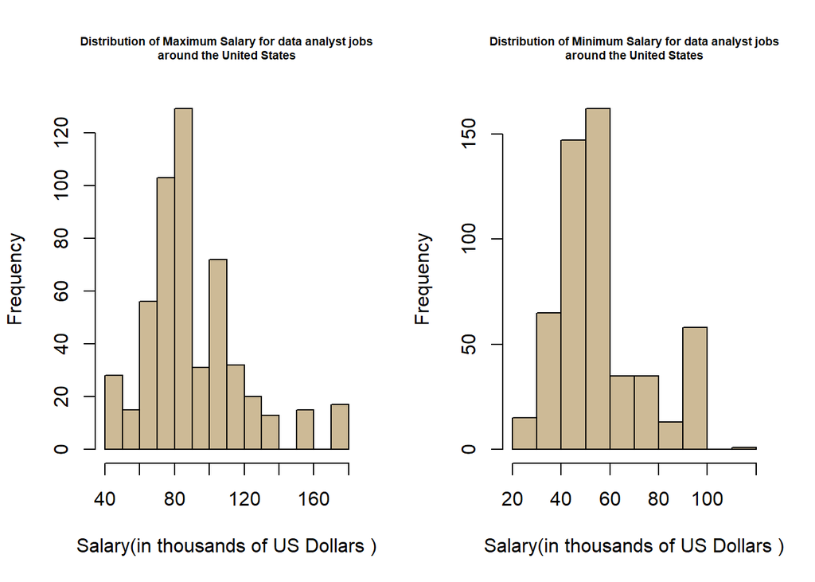

```r
#distribution of variables and identifying  outliers:

par(mfrow = c(1,2))

hist(df$max.salary,
     main = 'Distribution of Maximum Salary for data analyst jobs\naround the United States',
    cex.main = 0.6, xlab = 'Salary(in thousands of US Dollars )', col = 'wheat3')
hist(df$min.salary, main = 'Distribution of Minimum Salary for data analyst jobs\naround the United States',
    cex.main = 0.6, xlab = 'Salary(in thousands of US Dollars )', col = 'wheat3')
```

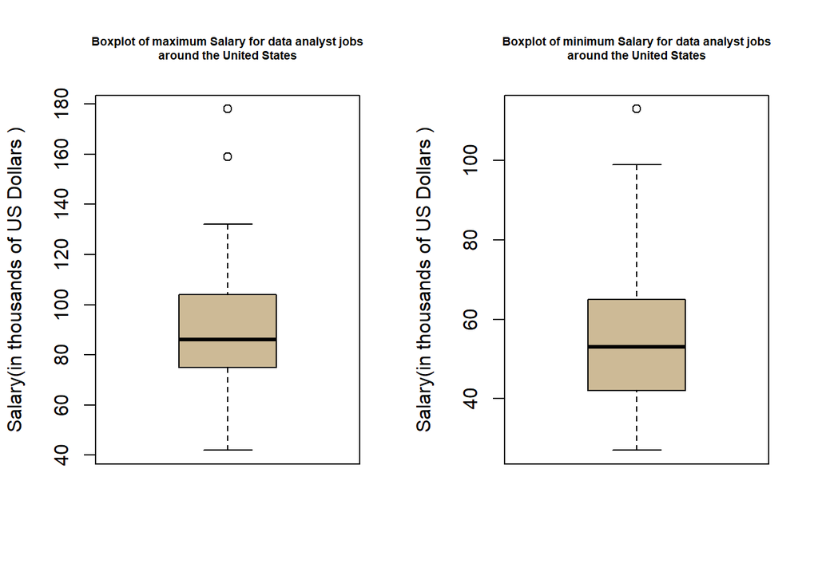

```r
boxplot(df$max.salary, main = 'Boxplot of maximum Salary for data analyst jobs\naround the United States',
       cex.main = 0.6, ylab = 'Salary(in thousands of US Dollars )', col = 'wheat3')
boxplot(df$min.salary, main = 'Boxplot of minimum Salary for data analyst jobs\naround the United States',
       cex.main = 0.6, ylab = 'Salary(in thousands of US Dollars )',  col = 'wheat3')
```

```r
par(mfrow = c(1,1))

# Shapiro Wilk test of normality
# Ho means that that population is not normally distribute(R-Coockbook. J.D Long & Paul Teetor 249p)

print("Max Salary: ")
```

```
## [1] "Max Salary: "
```

```r
shapiro.test(df$max.salary)
```

```
##
##  Shapiro-Wilk normality test
##
## data:  df$max.salary
## W = 0.91465, p-value < 2.2e-16
```

```r
print("Mim Salary: ")
```

```
## [1] "Mim Salary: "
```

```r
shapiro.test(df$min.salary)
```

```
##
##  Shapiro-Wilk normality test
##
## data:  df$min.salary
## W = 0.90539, p-value < 2.2e-16
```

### 2.1.2 Analyzing the categorical variable Type.of.ownership:

```r
table(df$Type.of.ownership)
```

```
##
##           College / University              Company - Private
##                              8                            317
##               Company - Public                       Hospital
##                            127                             10
##         Nonprofit Organization Subsidiary or Business Segment
##                             39                             30
```

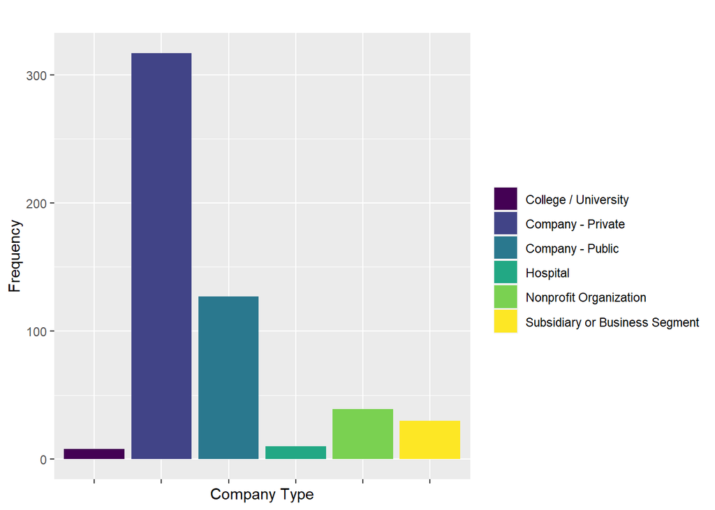

```r
library(ggplot2)

ggplot(df, aes(Type.of.ownership, fill = Type.of.ownership))+
geom_bar()+
ylab('Frequency')+
xlab('Company Type')+
ggtitle('')+
scale_x_discrete(labels = element_blank())+
scale_fill_viridis_d()+
guides(fill= guide_legend(title = NULL))
```

```r
table(df$Type.of.ownership)/length(df$Type.of.ownership)
```

```
##
##           College / University              Company - Private
##                     0.01506591                     0.59698682
##               Company - Public                       Hospital
##                     0.23917137                     0.01883239
##         Nonprofit Organization Subsidiary or Business Segment
##                     0.07344633                     0.05649718
```

```r
# Consulted: R-Graphics cookbook Winston Chang 194,254p
#            R-Documentation, ggplot2
#            https://stackoverflow.com/questions/35090883/remove-all-of-x-axis-labels-in-ggplot
#            https://stackoverflow.com/questions/35090883/remove-all-of-x-axis-labels-in-ggplot
```

## 2.2 Demonstrating the applicability of the Central Limit Theorem

The Central Limit Theorem states that if many samples of large enough sizes are drawn from a population with any type of distribution, its sampling distribution of the sample means will be approximately normally distributed with mu.xbar = mu and a standard deviation of sigma/sqrt(sample size).(Statistics James Mclave & Terry Sincich 285p).

In order for this theory to be applied, the samples drawn from the population need to be representative, meaning that every unit in the population needs to have the same chance of being selected (Statistics James Mclave & Terry Sincich 285p).

To comply with this, the population of this study is assumed to be the population of interest. From it, multiple samples will be drawn and the questions that were proposed at the beginning will attempt to be solved, and the estimators compared with the population parameters.

Many sampling methods will be used to draw multiple samples and build different sampling distributions of sample means. After that, the sampling method that yields the best results will be used to perform single sampling parametric and non parametric tests to answer the same questions.

### 2.2.1.1 Using population parameters

```r
# Caculating population parameters:

mean.func <- function(numeric.col.number, dataframe = df, categorical.col, category){
    m <- subset(dataframe, categorical.col == category)
    m <- m[[numeric.col.number]]
    m = mean(m)
    return(m)
}
print('Minimum Salary:')
```

```
## [1] "Minimum Salary:"
```

```r
print('New York: ')
```

```
## [1] "New York: "
```

```r
round(mean.func(1, df, df$Location, "New York, NY"), digits = 3)
```

```
## [1] 52.663
```

```r
print('Los Angeles: ')
```

```
## [1] "Los Angeles: "
```

```r
round(mean.func(1, df, df$Location, "Los Angeles, CA"), digits = 3)
```

```
## [1] 47.768
```

```r
print('San Francisco: ')
```

```
## [1] "San Francisco: "
```

```r
round(mean.func(1, df, df$Location, "San Francisco, CA"), digits = 3)
```

```
## [1] 72.425
```

```r
print('Austin: ')
```

```
## [1] "Austin: "
```

```r
round(mean.func(1, df, df$Location, "Austin, TX"), digits = 3)
```

```
## [1] 42.608
```

```r
print('Charlotte: ')
```

```
## [1] "Charlotte: "
```

```r
round(mean.func(1, df, df$Location, "Charlotte, NC"), digits = 3)
```

```
## [1] 50.836
```

```r
print('Chicago: ')
```

```
## [1] "Chicago: "
```

```r
round(mean.func(1, df, df$Location, "Chicago, IL"), digits = 3)
```

```
## [1] 68.375
```

```r
print('Maximum Salary:')
```

```
## [1] "Maximum Salary:"
```

```r
print('New York: ')
```

```
## [1] "New York: "
```

```r
round(mean.func(2, df, df$Location, "New York, NY"), digits = 3)
```

```
## [1] 87.262
```

```r
print('Los Angeles: ')
```

```
## [1] "Los Angeles: "
```

```r
round(mean.func(2, df, df$Location, "Los Angeles, CA"), digits = 3)
```

```
## [1] 80.911
```

```r
print('San Francisco: ')
```

```
## [1] "San Francisco: "
```

```r
round(mean.func(2, df, df$Location, "San Francisco, CA"), digits = 3)
```

```
## [1] 127.046
```

```r
print('Austin: ')
```

```
## [1] "Austin: "
```

```r
round(mean.func(2, df, df$Location, "Austin, TX"), digits = 3)
```

```
## [1] 72.471
```

```r
print('Charlotte: ')
```

```
## [1] "Charlotte: "
```

```r
round(mean.func(2, df, df$Location, "Charlotte, NC"), digits = 3)
```

```
## [1] 84.745
```

```r
print('Chicago: ')
```

```
## [1] "Chicago: "
```

```r
round(mean.func(2, df, df$Location, "Chicago, IL"), digits = 3)
```

```
## [1] 87.4
```

```
## notch went outside hinges. Try setting notch=FALSE.
```

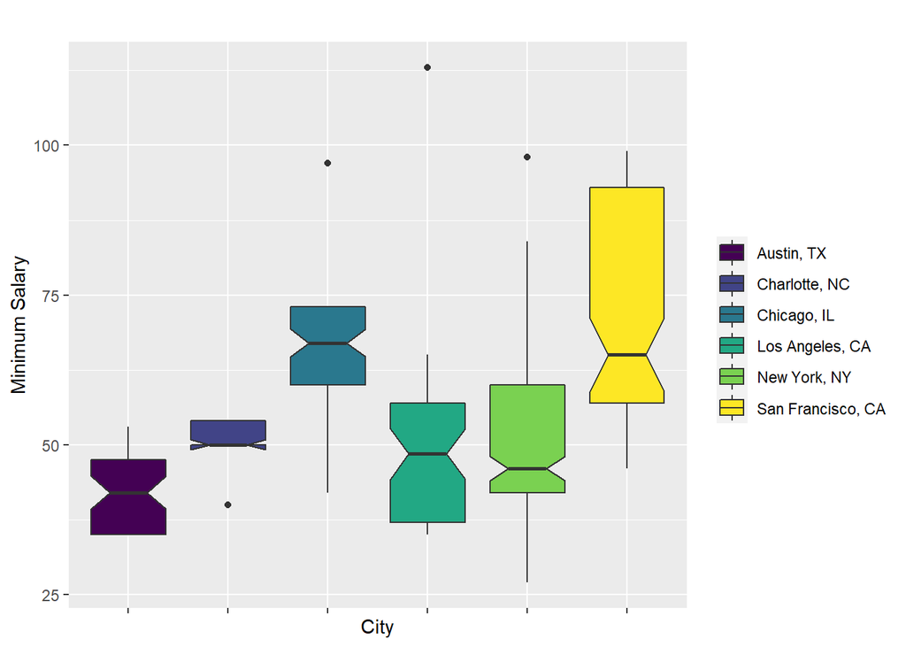

```r
# boxplot

box.chart <- function(dataframe, numeric.col, categorical.col, x, y, main, Fill){
    ggplot(dataframe, aes(y = numeric.col, x = categorical.col, fill = Fill))+
    geom_boxplot(notch = T)+
    scale_x_discrete(labels = element_blank())+
    scale_fill_viridis_d()+
    xlab(x)+
    ylab(y)+
    ggtitle(main)+
    theme(plot.title = element_text(hjust = 0.5, size = 13))+
    guides(fill= guide_legend(title = NULL))
}

# Consulted: R-Graphics cookbook Winston Chang 145,194,254,250p
#            R-Documentation, ggplot2 Theme elements
#            https://stackoverflow.com/questions/35090883/remove-all-of-x-axis-labels-in-ggplot
#

box.chart(df, df$min.salary, df$Location, 'City', 'Minimum Salary', '', df$Location)
```

```
## notch went outside hinges. Try setting notch=FALSE.
```

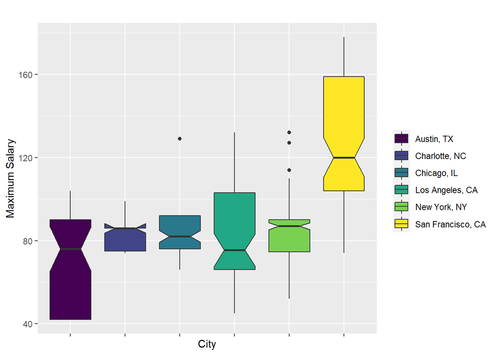

```r
box.chart(df, df$max.salary, df$Location, 'City', 'Maximum Salary', '', df$Location)
```

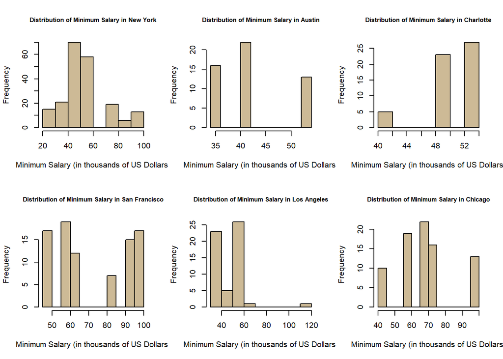

```r
# distribution by factor:


NY <- subset(df, Location == "New York, NY")


AU <- subset(df, Location == "Austin, TX")


CHAR <- subset(df, Location == "Charlotte, NC")


SF <- subset(df, Location == "San Francisco, CA")


LA <- subset(df, Location == "Los Angeles, CA")


CHI <- subset(df, Location == "Chicago, IL")


distrib <- function(dataframe, numeric.col.number, x, y, main){
    hist(dataframe[[1]], xlab = x, ylab = y, main = main, col = 'wheat3', cex.main = 0.8)
}

par(mfrow = c(2,3))

distrib(NY, 1, 'Minimum Salary (in thousands of US Dollars)', 'Frequency', 'Distribution of Minimum Salary in New York')
distrib(AU, 1, 'Minimum Salary (in thousands of US Dollars)', 'Frequency', 'Distribution of Minimum Salary in Austin')
distrib(CHAR, 1, 'Minimum Salary (in thousands of US Dollars)', 'Frequency', 'Distribution of Minimum Salary in Charlotte')
distrib(SF, 1, 'Minimum Salary (in thousands of US Dollars)', 'Frequency', 'Distribution of Minimum Salary in San Francisco')
distrib(LA, 1, 'Minimum Salary (in thousands of US Dollars)', 'Frequency', 'Distribution of Minimum Salary in Los Angeles')
distrib(CHI, 1, 'Minimum Salary (in thousands of US Dollars)', 'Frequency', 'Distribution of Minimum Salary in Chicago')
```

[figure not shown]

```r
par(mfrow = c(1,1))

par(mfrow = c(2,3))

distrib(NY, 2, 'Maximum Salary (in thousands of US Dollars)', 'Frequency', 'Distribution of Maximum Salary in New York')
distrib(AU, 2, 'Maximum Salary (in thousands of US Dollars)', 'Frequency', 'Distribution of Maximum Salary in Austin')
distrib(CHAR, 2, 'Maximum Salary (in thousands of US Dollars)', 'Frequency', 'Distribution of Maximum Salary in Charlotte')
distrib(SF, 2, 'Maximum Salary (in thousands of US Dollars)', 'Frequency', 'Distribution of Maximum Salary in San Francisco')
distrib(LA, 2, 'Maximum Salary (in thousands of US Dollars)', 'Frequency', 'Distribution of Maximum Salary in Los Angeles')
distrib(CHI, 2, 'Maximum Salary (in thousands of US Dollars)', 'Frequency', 'Distribution of Maximum Salary in Chicago')
```

```r
par(mfrow = c(1,1))

# Shapiro Wilk test of normality
# Ho means that that population is not normally distribute(R-Coockbook. J.D Long & Paul Teetor 249p)

print("Company Minimum Salary: ")
```

```
## [1] "Company Minimum Salary: "
```

```r
shapiro.test(NY[[1]])
```

```
##
##  Shapiro-Wilk normality test
##
## data:  NY[[1]]
## W = 0.88231, p-value = 1.841e-11
```

```r
shapiro.test(LA[[1]])
```

```
##
##  Shapiro-Wilk normality test
##
## data:  LA[[1]]
## W = 0.71791, p-value = 4.658e-09
```

```r
shapiro.test(SF[[1]])
```

```
##
##  Shapiro-Wilk normality test
##
## data:  SF[[1]]
## W = 0.84275, p-value = 3.541e-08
```

```r
shapiro.test(AU[[1]])
```

```
##
##  Shapiro-Wilk normality test
##
## data:  AU[[1]]
## W = 0.78923, p-value = 4.093e-07
```

```r
shapiro.test(CHAR[[1]])
```

```
##
##  Shapiro-Wilk normality test
##
## data:  CHAR[[1]]
## W = 0.68225, p-value = 1.251e-09
```

```r
shapiro.test(CHI[[1]])
```

```
##
##  Shapiro-Wilk normality test
##
## data:  CHI[[1]]
## W = 0.871, p-value = 8.821e-07
```

```r
# Shapiro Wilk test of normality
# Ho means that that population is not normally distribute(R-Coockbook. J.D Long & Paul Teetor 249p)

print("Company Maximum Salary: ")
```

```
## [1] "Company Maximum Salary: "
```

```r
shapiro.test(NY[[2]])
```

```
##
##  Shapiro-Wilk normality test
##
## data:  NY[[2]]
## W = 0.92273, p-value = 8.126e-09
```

```r
shapiro.test(LA[[2]])
```

```
##
##  Shapiro-Wilk normality test
##
## data:  LA[[2]]
## W = 0.81557, p-value = 6.81e-07
```

```r
shapiro.test(SF[[2]])
```

```
##
##  Shapiro-Wilk normality test
##
## data:  SF[[2]]
## W = 0.87354, p-value = 4.569e-07
```

```r
shapiro.test(AU[[2]])
```

```
##
##  Shapiro-Wilk normality test
##
## data:  AU[[2]]
## W = 0.80564, p-value = 9.786e-07
```

```r
shapiro.test(CHAR[[2]])
```

```
##
##  Shapiro-Wilk normality test
##
## data:  CHAR[[2]]
## W = 0.81123, p-value = 6.345e-07
```

```r
shapiro.test(CHI[[2]])
```

```
##
##  Shapiro-Wilk normality test
##
## data:  CHI[[2]]
## W = 0.80109, p-value = 5.097e-09
```

### 2.2.1.2 Using Central Limit Theorem

```r
set.seed(900)

# function that returns the means of 1000 samples of size 100

simple <- function(nsamples, df, size, numeric.variable.number){
    xbar = numeric(nsamples)
    for (i in 1:nsamples){
        xbar[i]  = mean(sample(df[[numeric.variable.number]], size = size, replace = T))

    }
return(xbar)
}

# consulted: Lecture 8 samples, MET CS544
print('Min Salary :')
```

```
## [1] "Min Salary :"
```

```r
print('New York: ')
```

```
## [1] "New York: "
```

```r
sprintf('The average minimum salary for the population and sampling mean is %g and %g respectively',
        mean(NY$min.salary),mean(simple(1000, NY, 100, 1)) )
```

```
## [1] "The average minimum salary for the population and sampling mean is 52.6634 and 52.6355 respectively"
```

```r
print('Los Angeles: ')
```

```
## [1] "Los Angeles: "
```

```r
sprintf('The average minimum salary for the population and sampling mean is %g and %g respectively',
        mean(LA$min.salary),mean(simple(1000, LA, 100, 1)) )
```

```
## [1] "The average minimum salary for the population and sampling mean is 47.7679 and 47.723 respectively"
```

```r
print('San Francisco: ')
```

```
## [1] "San Francisco: "
```

```r
sprintf('The average minimum salary for the population and sampling mean is %g and %g respectively',
        mean(SF$min.salary),mean(simple(1000, SF, 100, 1)) )
```

```
## [1] "The average minimum salary for the population and sampling mean is 72.4253 and 72.4201 respectively"
```

```r
print('Austin: ')
```

```
## [1] "Austin: "
```

```r
sprintf('The average minimum salary for the population and sampling mean is %g and %g respectively',
        mean(AU$min.salary),mean(simple(1000, AU, 100, 1)) )
```

```
## [1] "The average minimum salary for the population and sampling mean is 42.6078 and 42.5921 respectively"
```

```r
print('Charlotte: ')
```

```
## [1] "Charlotte: "
```

```r
sprintf('The average minimum salary for the population and sampling mean is %g and %g respectively',
        mean(CHAR$min.salary),mean(simple(1000, CHAR, 100, 1)) )
```

```
## [1] "The average minimum salary for the population and sampling mean is 50.8364 and 50.8471 respectively"
```

```r
print('Chicago: ')
```

```
## [1] "Chicago: "
```

```r
sprintf('The average minimum salary for the population and sampling mean is %g and %g respectively',
        mean(CHI$min.salary),mean(simple(1000, CHI, 100, 1)) )
```

```
## [1] "The average minimum salary for the population and sampling mean is 68.375 and 68.4073 respectively"
```

```r
print('Max Salary :')
```

```
## [1] "Max Salary :"
```

```r
print('New York: ')
```

```
## [1] "New York: "
```

```r
sprintf('The average maximum salary for the population and sampling mean is %g and %g respectively',
        mean(NY$max.salary),mean(simple(1000, NY, 100, 2)) )
```

```
## [1] "The average maximum salary for the population and sampling mean is 87.2624 and 87.2136 respectively"
```

```r
print('Los Angeles: ')
```

```
## [1] "Los Angeles: "
```

```r
sprintf('The average maximum salary for the population and sampling mean is %g and %g respectively',
        mean(LA$max.salary),mean(simple(1000, LA, 100, 2)) )
```

```
## [1] "The average maximum salary for the population and sampling mean is 80.9107 and 80.8581 respectively"
```

```r
print('San Francisco: ')
```

```
## [1] "San Francisco: "
```

```r
sprintf('The average maximum salary for the population and sampling mean is %g and %g respectively',
        mean(SF$max.salary),mean(simple(1000, SF, 100, 2)) )
```

```
## [1] "The average maximum salary for the population and sampling mean is 127.046 and 126.846 respectively"
```

```r
print('Austin: ')
```

```
## [1] "Austin: "
```

```r
sprintf('The average maximum salary for the population and sampling mean is %g and %g respectively',
        mean(AU$max.salary),mean(simple(1000, AU, 100, 2)) )
```

```
## [1] "The average maximum salary for the population and sampling mean is 72.4706 and 72.5148 respectively"
```

```r
print('Charlotte: ')
```

```
## [1] "Charlotte: "
```

```r
sprintf('The average maximum salary for the population and sampling mean is %g and %g respectively',
        mean(CHAR$max.salary),mean(simple(1000, CHAR, 100, 2)) )
```

```
## [1] "The average maximum salary for the population and sampling mean is 84.7455 and 84.7793 respectively"
```

```r
print('Chicago: ')
```

```
## [1] "Chicago: "
```

```r
sprintf('The average maximum salary for the population and sampling mean is %g and %g respectively',
        mean(CHI$max.salary),mean(simple(1000, CHI, 100, 2)) )
```

```
## [1] "The average maximum salary for the population and sampling mean is 87.4 and 87.3053 respectively"
```

```r
# barplot function. Plotting confidence intervals

bar.chart <- function(dataframe, numeric.col1, numeric.col2, categorical.col, x, y, main){
    ggplot(dataframe , aes(x = categorical.col, y = numeric.col1, fill = categorical.col))+
    geom_bar(stat = 'identity')+
    geom_errorbar(aes(ymin = numeric.col1 - numeric.col2,
               ymax = numeric.col1 + numeric.col2), width=.1,
                 position=position_dodge(.9))+
    scale_fill_viridis_d()+
    xlab(x)+
    ylab(y)+
    ggtitle(main)+
    theme(plot.title = element_text(hjust = 0.5, size = 13))+
    guides(fill= guide_legend(title = NULL))


}


# Consulted: R-Graphics cookbook Winston Chang 194,250, 254p
#            R-Documentation, ggplot2 Theme elements

# http://environmentalcomputing.net/plotting-with-ggplot-bar-plots-with-error-bars/

# Looking at the differences with confidence intervals: Minimum Salary

min.bars <- rbind( cbind(Name = rep('Ney York', times = 1000 ), min.salary = simple(1000, NY, 100, 1), margin = qnorm(0.025, lower.tail = F)*sd(simple(1000, NY, 100, 1))),
                   cbind(Name = rep('Los Angeles', times = 1000 ), min.salary = simple(1000, LA, 100, 1), margin = qnorm(0.025, lower.tail = F)*sd(simple(1000, LA, 100, 1))),
                   cbind(Name = rep('San Francisco', times = 1000 ), min.salary = simple(1000, SF, 100, 1), margin = qnorm(0.025, lower.tail = F)*sd(simple(1000, SF, 100, 1))),
                   cbind(Name = rep('Austin', times = 1000 ), min.salary = simple(1000, AU, 100, 1), margin = qnorm(0.025, lower.tail = F)*sd(simple(1000, AU, 100, 1))),
                   cbind(Name = rep('Charlotte', times = 1000 ), min.salary = simple(1000, CHAR, 100, 1), margin = qnorm(0.025, lower.tail = F)*sd(simple(1000, CHAR, 100, 1))),
                   cbind(Name = rep('Chicago', times = 1000 ), min.salary = simple(1000, CHI, 100, 1), margin = qnorm(0.025, lower.tail = F)*sd(simple(1000, CHI, 100, 1))))


library(dplyr)
min.bars <- as.data.frame(min.bars) # transforming into data frame
min.bars$min.salary <- as.numeric(as.character(min.bars$min.salary))  # transforming numeric column to integer
min.bars$margin <- as.numeric(as.character(min.bars$margin))

min.bars.summary <- min.bars %>% group_by(Name) %>% summarise(mean = mean(min.salary), margin = mean(margin))
min.bars.summary
```

```
## # A tibble: 6 x 3
##   Name           mean margin
##   <chr>         <dbl>  <dbl>
## 1 Austin         42.6  1.35
## 2 Charlotte      50.8  0.776
## 3 Chicago        68.3  3.07
## 4 Los Angeles    47.8  2.60
## 5 Ney York       52.7  3.62
## 6 San Francisco  72.4  3.97
```

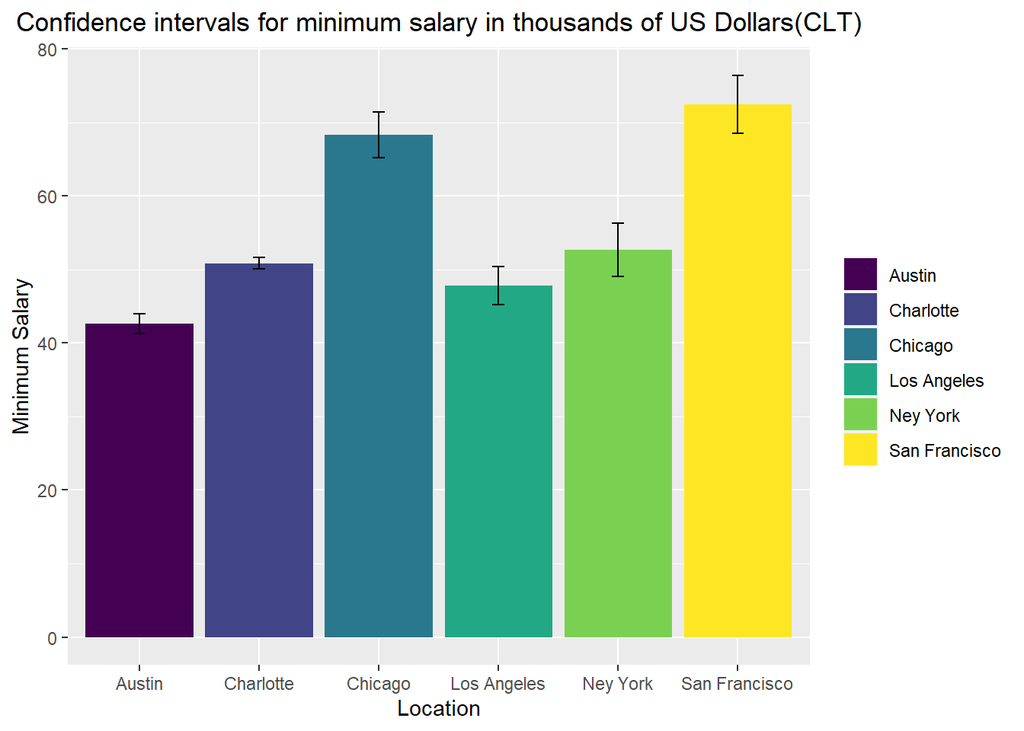

```r
# consulted: # https://stackoverflow.com/questions/26391921/how-to-convert-entire-dataframe-to-numeric-while-preserving-decimals
bar.chart(min.bars.summary, min.bars.summary$mean,
          min.bars.summary$margin, min.bars.summary$Name, "Location", 'Minimum Salary', 'Confidence intervals for minimum salary in thousands of US Dollars(CLT)' )
```

```r
# Looking at the differences with confidence intervals: Maximum Salary

max.bars <- rbind( cbind(Name = rep('New York', times = 1000 ), max.salary = simple(1000, NY, 100, 2), margin = qnorm(0.025, lower.tail = F)*sd(simple(1000, NY, 100, 2))),
                   cbind(Name = rep('Los Angeles', times = 1000 ), max.salary = simple(1000, LA, 100, 2), margin = qnorm(0.025, lower.tail = F)*sd(simple(1000, LA, 100, 2))),
                   cbind(Name = rep('San Francisco', times = 1000 ), max.salary = simple(1000, SF, 100, 2), margin = qnorm(0.025, lower.tail = F)*sd(simple(1000, SF, 100, 2))),
                   cbind(Name = rep('Austin', times = 1000 ), max.salary = simple(1000, AU, 100, 2), margin = qnorm(0.025, lower.tail = F)*sd(simple(1000, AU, 100, 2))),
                   cbind(Name = rep('Charlotte', times = 1000 ), max.salary = simple(1000, CHAR, 100, 2), margin = qnorm(0.025, lower.tail = F)*sd(simple(1000, CHAR, 100, 2))),
                   cbind(Name = rep('Chicago', times = 1000 ), max.salary = simple(1000, CHI, 100, 2), margin = qnorm(0.025, lower.tail = F)*sd(simple(1000, CHI, 100, 2))))



max.bars <- as.data.frame(max.bars) # transforming into data frame
max.bars$max.salary <- as.numeric(as.character(max.bars$max.salary))  # transforming numeric column to integer
max.bars$margin <- as.numeric(as.character(max.bars$margin))

max.bars.summary <- max.bars %>% group_by(Name) %>% summarise(mean = mean(max.salary), margin = mean(margin))
# consulted: # https://stackoverflow.com/questions/26391921/how-to-convert-entire-dataframe-to-numeric-while-preserving-decimals

max.bars.summary
```

```
## # A tibble: 6 x 3
##   Name           mean margin
##   <chr>         <dbl>  <dbl>
## 1 Austin         72.4   4.43
## 2 Charlotte      84.7   1.78
## 3 Chicago        87.4   4.12
## 4 Los Angeles    81.0   4.92
## 5 New York       87.2   4.03
## 6 San Francisco 127.    6.90
```

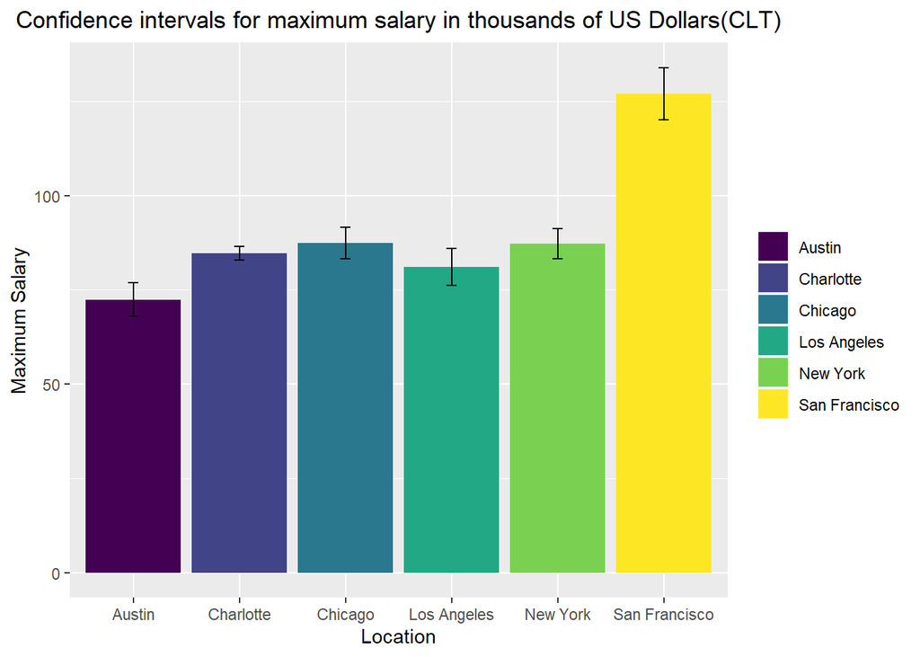

```r
bar.chart(max.bars.summary, max.bars.summary$mean,
          max.bars.summary$margin, max.bars.summary$Name, "Location", 'Maximum Salary', 'Confidence intervals for maximum salary in thousands of US Dollars(CLT)' )
```

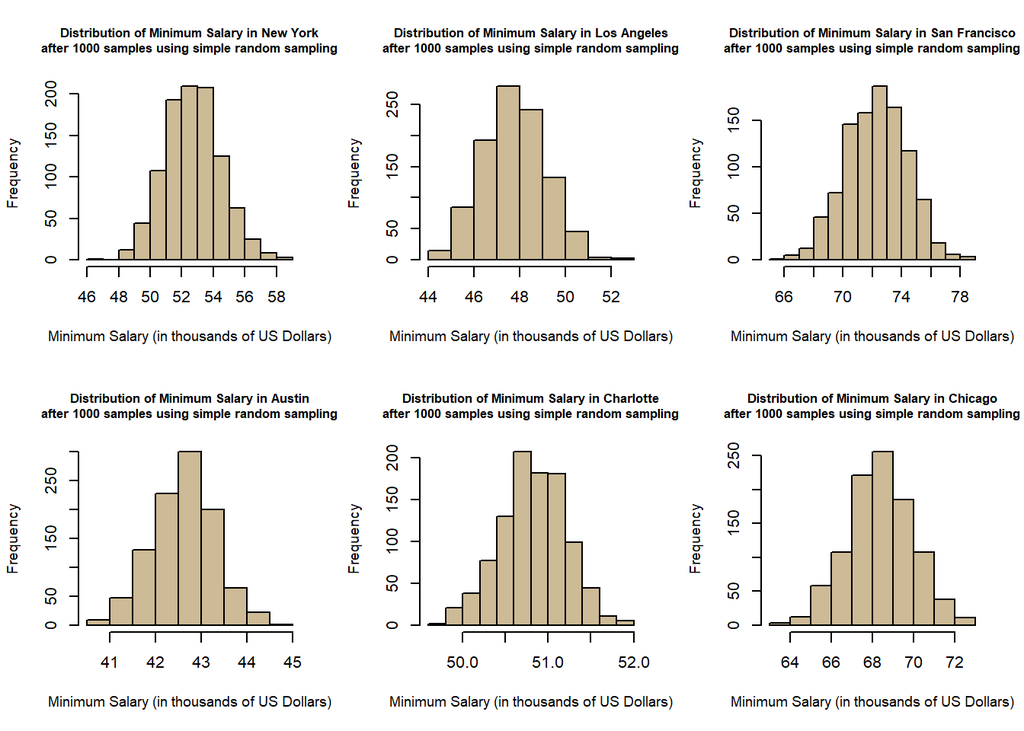

```r
# Checking the new distributions:


distrib.cl <- function(mean, x, y, main){
    hist(mean, xlab = x, ylab = y, main = main, col = 'wheat3', cex.main = 0.8, cex.lab = 0.9)
}

par(mfrow = c(2,3))

distrib.cl(simple(1000, NY, 100, 1),
           'Minimum Salary (in thousands of US Dollars)', 'Frequency',
           'Distribution of Minimum Salary in New York\nafter 1000 samples using simple random sampling' )

distrib.cl(simple(1000, LA, 100, 1),
           'Minimum Salary (in thousands of US Dollars)', 'Frequency',
           'Distribution of Minimum Salary in Los Angeles\nafter 1000 samples using simple random sampling' )


distrib.cl(simple(1000, SF, 100, 1),
           'Minimum Salary (in thousands of US Dollars)', 'Frequency',
           'Distribution of Minimum Salary in San Francisco\nafter 1000 samples using simple random sampling' )

distrib.cl(simple(1000, AU, 100, 1),
           'Minimum Salary (in thousands of US Dollars)', 'Frequency',
           'Distribution of Minimum Salary in Austin\nafter 1000 samples using simple random sampling' )

distrib.cl(simple(1000, CHAR, 100, 1),
           'Minimum Salary (in thousands of US Dollars)', 'Frequency',
           'Distribution of Minimum Salary in Charlotte\nafter 1000 samples using simple random sampling' )

distrib.cl(simple(1000, CHI, 100, 1),
           'Minimum Salary (in thousands of US Dollars)', 'Frequency',
           'Distribution of Minimum Salary in Chicago\nafter 1000 samples using simple random sampling' )
```

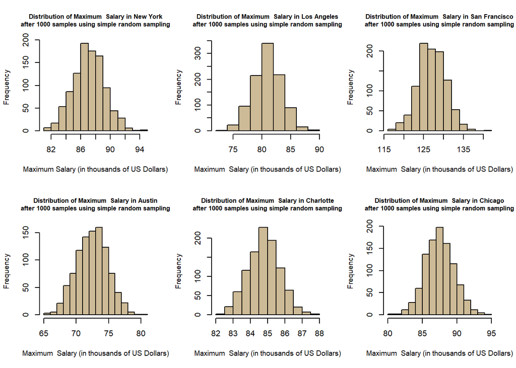

```r
par(mfrow = c(1,1))

par(mfrow = c(2,3))

distrib.cl(simple(1000, NY, 100, 2),
           'Maximum Salary (in thousands of US Dollars)', 'Frequency',
           'Distribution of Maximum  Salary in New York\nafter 1000 samples using simple random sampling' )

distrib.cl(simple(1000, LA, 100, 2),
           'Maximum  Salary (in thousands of US Dollars)', 'Frequency',
           'Distribution of Maximum  Salary in Los Angeles\nafter 1000 samples using simple random sampling' )


distrib.cl(simple(1000, SF, 100, 2),
           'Maximum  Salary (in thousands of US Dollars)', 'Frequency',
           'Distribution of Maximum  Salary in San Francisco\nafter 1000 samples using simple random sampling' )

distrib.cl(simple(1000, AU, 100, 2),
           'Maximum  Salary (in thousands of US Dollars)', 'Frequency',
           'Distribution of Maximum  Salary in Austin\nafter 1000 samples using simple random sampling' )

distrib.cl(simple(1000, CHAR, 100, 2),
           'Maximum  Salary (in thousands of US Dollars)', 'Frequency',
           'Distribution of Maximum  Salary in Charlotte\nafter 1000 samples using simple random sampling' )

distrib.cl(simple(1000, CHI, 100, 2),
           'Maximum  Salary (in thousands of US Dollars)', 'Frequency',
           'Distribution of Maximum  Salary in Chicago\nafter 1000 samples using simple random sampling' )
```

```r
par(mfrow = c(1,1))
```

The sampling distribution of the sample mean of salaries is almost identical to the population parameter salary per different cities.

### 2.2.1.3 Using Parametric and Non-Parametric tests

#### Simple Random sampling

```r
#install.packages("sampling")
set.seed(200)
library(sampling)
s <- function(df, n){
    x = srswor(n, nrow(df))
    r = (1:nrow(df))[x==1]
    s = df[r,]
    return(s)

}


Simple100 <- s(df, 100)
Simple28 <-  s(df, 28)


# Consulted: R - Documentation Random Samples and Permutations,
#            Simple random sampling without replacement
#            Lecture6_rsamples, lecture8_Rsamples
summary(Simple28)
```

```
##    min.salary      max.salary                  Location
##  Min.   :27.00   Min.   : 42.00   Austin, TX       : 3
##  1st Qu.:40.00   1st Qu.: 74.00   Charlotte, NC    : 3
##  Median :44.00   Median : 80.00   Chicago, IL      : 5
##  Mean   :55.21   Mean   : 90.61   Los Angeles, CA  : 2
##  3rd Qu.:67.00   3rd Qu.:106.50   New York, NY     :11
##  Max.   :99.00   Max.   :178.00   San Francisco, CA: 4
##                       Type.of.ownership
##  College / University          : 1
##  Company - Private             :14
##  Company - Public              : 9
##  Hospital                      : 0
##  Nonprofit Organization        : 3
##  Subsidiary or Business Segment: 1
```

#### Systematic Sampling

```r
set.seed(201)
sys <- function(df, n){
    k = ceiling(nrow(df)/n)
    r = sample(k, 1)
    s =  seq(from = r, by = k, length = n)
    s <- df[s,]
    return(s)
}

Sys100 <- sys(df, 100)
Sys100 <- na.omit(Sys100)# remove NANs at the tail

# Consulted: R- Documentation Random Samples and Permutations,
#            Simple random sampling without replacement
#            Lecture6_rsamples, lecture8_Rsamples
#            CS544 Study Guide Module 5 Sampling and Errors
```

```r
set.seed(202)
sysp <- function(df,col, n){
    category.number =
    prob = inclusionprobabilities(as.numeric(col), n)
    sys = UPsystematic(prob)
    s = df[sys == 1,]
    return(s)
}
Sysp100 <- sysp(df, df$Location, 100)
# Consulted: R- Documentation Random Samples and Permutations,
#            Simple random sampling without replacement
#            Lecture6_rsamples, lecture8_Rsamples
#            CS544 Study Guide Module 5 Sampling and Errors
```

#### Stratified sampling

```r
# ordering using Location:
set.seed(203)
strat <- function(df, col.number, n, colname){
    ord = order(df[[col.number]])
    data = df[ord,]
    table = table(data[[col.number]])
    size =  round((n * table)/sum(table))
    s = strata(data, size = size, method = "srswor", stratanames = c(colname))
    s = getdata(data, s)
    return(s)
}

Strat100 <- strat(df, 2, 100, 'Location')
```

#### Parametric Tests

##### Minimum Salary

```r
##### Sampling distribution:

# note that min.bars and max.bars contain the sampling distribution of the
# sample means for min.salary and max.salary per city respectively

salary <- aov(min.salary ~ Name, data = min.bars)
summary(salary)
```

```
##               Df Sum Sq Mean Sq F value Pr(>F)
## Name           5 705768  141154   68241 <2e-16 ***
## Residuals   5994  12398       2
## ---
## Signif. codes:  0 '***' 0.001 '**' 0.01 '*' 0.05 '.' 0.1 ' ' 1
```

```r
# Post Hoc:
pairwise.t.test(min.bars$min.salary, min.bars$Name, p.adj = 'bonferroni')
```

```
##
##  Pairwise comparisons using t tests with pooled SD
##
## data:  min.bars$min.salary and min.bars$Name
##
##               Austin Charlotte Chicago Los Angeles Ney York
## Charlotte     <2e-16 -         -       -           -
## Chicago       <2e-16 <2e-16    -       -           -
## Los Angeles   <2e-16 <2e-16    <2e-16  -           -
## Ney York      <2e-16 <2e-16    <2e-16  <2e-16      -
## San Francisco <2e-16 <2e-16    <2e-16  <2e-16      <2e-16
##
## P value adjustment method: bonferroni
```

```r
# Simple Random Sampling:

salary <- aov(min.salary ~ Location, data = Simple100)
summary(salary)
```

```
##             Df Sum Sq Mean Sq F value   Pr(>F)
## Location     5   9055  1811.0   6.755 2.02e-05 ***
## Residuals   94  25201   268.1
## ---
## Signif. codes:  0 '***' 0.001 '**' 0.01 '*' 0.05 '.' 0.1 ' ' 1
```

```r
# Post Hoc:
pairwise.t.test(Simple100$min.salary, Simple100$Location, p.adj = 'bonferroni')
```

```
##
##  Pairwise comparisons using t tests with pooled SD
##
## data:  Simple100$min.salary and Simple100$Location
##
##                   Austin, TX Charlotte, NC Chicago, IL Los Angeles, CA
## Charlotte, NC     1.00000    -             -           -
## Chicago, IL       0.00201    0.13410       -           -
## Los Angeles, CA   1.00000    1.00000       0.01900     -
## New York, NY      0.74385    1.00000       0.05248     1.00000
## San Francisco, CA 0.00064    0.07205       1.00000     0.00672
##                   New York, NY
## Charlotte, NC     -
## Chicago, IL       -
## Los Angeles, CA   -
## New York, NY      -
## San Francisco, CA 0.01371
##
## P value adjustment method: bonferroni
```

```r
# Testing with a smaller sample:

salary.small <- aov(min.salary ~ Location, data = Simple28)
summary(salary.small)
```

```
##             Df Sum Sq Mean Sq F value Pr(>F)
## Location     5   4208   841.6   1.831  0.148
## Residuals   22  10115   459.8
```

```r
# Post Hoc:
pairwise.t.test(Simple28$min.salary, Simple28$Location, p.adj = 'bonferroni')
```

```
##
##  Pairwise comparisons using t tests with pooled SD
##
## data:  Simple28$min.salary and Simple28$Location
##
##                   Austin, TX Charlotte, NC Chicago, IL Los Angeles, CA
## Charlotte, NC     1.00       -             -           -
## Chicago, IL       1.00       1.00          -           -
## Los Angeles, CA   1.00       1.00          1.00        -
## New York, NY      1.00       1.00          1.00        1.00
## San Francisco, CA 0.91       1.00          1.00        1.00
##                   New York, NY
## Charlotte, NC     -
## Chicago, IL       -
## Los Angeles, CA   -
## New York, NY      -
## San Francisco, CA 0.64
##
## P value adjustment method: bonferroni
```

```r
# Consulted: R-Documentation. Compute Tukey Honest Significant Differences
#            R - Documentation Fit an Analysis of Variance Model

# Systematic Random Sampling:

salary <- aov(min.salary ~ Location, data = Sys100)
summary(salary)
```

```
##             Df Sum Sq Mean Sq F value   Pr(>F)
## Location     5   9219  1843.9   7.179 1.26e-05 ***
## Residuals   83  21319   256.9
## ---
## Signif. codes:  0 '***' 0.001 '**' 0.01 '*' 0.05 '.' 0.1 ' ' 1
```

```r
# Post Hoc:
pairwise.t.test(Sys100$min.salary, Sys100$Location, p.adj = 'bonferroni')
```

```
##
##  Pairwise comparisons using t tests with pooled SD
##
## data:  Sys100$min.salary and Sys100$Location
##
##                   Austin, TX Charlotte, NC Chicago, IL Los Angeles, CA
## Charlotte, NC     1.00000    -             -           -
## Chicago, IL       0.00642    0.23292       -           -
## Los Angeles, CA   1.00000    1.00000       0.08163     -
## New York, NY      1.00000    1.00000       0.07205     1.00000
## San Francisco, CA 0.00022    0.01728       1.00000     0.00469
##                   New York, NY
## Charlotte, NC     -
## Chicago, IL       -
## Los Angeles, CA   -
## New York, NY      -
## San Francisco, CA 0.00111
##
## P value adjustment method: bonferroni
```

```r
# Consulted: R-Documentation. Compute Tukey Honest Significant Differences
#            R - Documentation Fit an Analysis of Variance Model

# Systematic Random Sampling with inclusion probabilities:

salary <- aov(min.salary ~ Location, data = Sysp100)
summary(salary)
```

```
##             Df Sum Sq Mean Sq F value   Pr(>F)
## Location     5   9353  1870.5   5.452 0.000189 ***
## Residuals   94  32250   343.1
## ---
## Signif. codes:  0 '***' 0.001 '**' 0.01 '*' 0.05 '.' 0.1 ' ' 1
```

```r
# Post Hoc:
pairwise.t.test(Sysp100$min.salary, Sysp100$Location, p.adj = 'bonferroni')
```

```
##
##  Pairwise comparisons using t tests with pooled SD
##
## data:  Sysp100$min.salary and Sysp100$Location
##
##                   Austin, TX Charlotte, NC Chicago, IL Los Angeles, CA
## Charlotte, NC     1.00000    -             -           -
## Chicago, IL       0.43372    1.00000       -           -
## Los Angeles, CA   1.00000    1.00000       0.45557     -
## New York, NY      1.00000    1.00000       0.11761     1.00000
## San Francisco, CA 0.18177    0.33297       1.00000     0.04307
##                   New York, NY
## Charlotte, NC     -
## Chicago, IL       -
## Los Angeles, CA   -
## New York, NY      -
## San Francisco, CA 0.00055
##
## P value adjustment method: bonferroni
```

```r
# Consulted: R-Documentation. Compute Tukey Honest Significant Differences
#            R - Documentation Fit an Analysis of Variance Model

# Stratified random Sampling:

salary <- aov(min.salary ~ Location, data = Strat100)
summary(salary)
```

```
##             Df Sum Sq Mean Sq F value Pr(>F)
## Location     5   2103   420.5   3.342 0.0277 *
## Residuals   17   2139   125.8
## ---
## Signif. codes:  0 '***' 0.001 '**' 0.01 '*' 0.05 '.' 0.1 ' ' 1
```

```r
# Post Hoc:
pairwise.t.test(Strat100$min.salary, Strat100$Location, p.adj = 'bonferroni')
```

```
##
##  Pairwise comparisons using t tests with pooled SD
##
## data:  Strat100$min.salary and Strat100$Location
##
##                   Austin, TX Charlotte, NC Chicago, IL Los Angeles, CA
## Charlotte, NC     1.000      -             -           -
## Chicago, IL       0.081      0.899         -           -
## Los Angeles, CA   1.000      1.000         0.518       -
## New York, NY      1.000      1.000         1.000       1.000
## San Francisco, CA 1.000      1.000         0.110       1.000
##                   New York, NY
## Charlotte, NC     -
## Chicago, IL       -
## Los Angeles, CA   -
## New York, NY      -
## San Francisco, CA 1.000
##
## P value adjustment method: bonferroni
```

```r
# Consulted: R-Documentation. Compute Tukey Honest Significant Differences
#            R - Documentation Fit an Analysis of Variance Model
```

##### Maximum Salary:

```r
##### Sampling distribution:

salary <- aov(max.salary ~ Name, data = max.bars)
summary(salary)
```

```
##               Df  Sum Sq Mean Sq F value Pr(>F)
## Name           5 1804218  360844   65708 <2e-16 ***
## Residuals   5994   32917       5
## ---
## Signif. codes:  0 '***' 0.001 '**' 0.01 '*' 0.05 '.' 0.1 ' ' 1
```

```r
# Post Hoc:
pairwise.t.test(max.bars$max.salary, min.bars$Name, p.adj = 'bonferroni')
```

```
##
##  Pairwise comparisons using t tests with pooled SD
##
## data:  max.bars$max.salary and min.bars$Name
##
##               Austin Charlotte Chicago Los Angeles Ney York
## Charlotte     <2e-16 -         -       -           -
## Chicago       <2e-16 <2e-16    -       -           -
## Los Angeles   <2e-16 <2e-16    <2e-16  -           -
## Ney York      <2e-16 <2e-16    1       <2e-16      -
## San Francisco <2e-16 <2e-16    <2e-16  <2e-16      <2e-16
##
## P value adjustment method: bonferroni
```

```r
# Simple Random Sampling:

salary <- aov(max.salary ~ Location, data = Simple100)
summary(salary)
```

```
##             Df Sum Sq Mean Sq F value   Pr(>F)
## Location     5  24540    4908    7.55 5.36e-06 ***
## Residuals   94  61107     650
## ---
## Signif. codes:  0 '***' 0.001 '**' 0.01 '*' 0.05 '.' 0.1 ' ' 1
```

```r
# Post Hoc:
pairwise.t.test(Simple100$max.salary, Simple100$Location, p.adj = 'bonferroni')
```

```
##
##  Pairwise comparisons using t tests with pooled SD
##
## data:  Simple100$max.salary and Simple100$Location
##
##                   Austin, TX Charlotte, NC Chicago, IL Los Angeles, CA
## Charlotte, NC     1.00000    -             -           -
## Chicago, IL       1.00000    1.00000       -           -
## Los Angeles, CA   1.00000    1.00000       1.00000     -
## New York, NY      0.34687    1.00000       1.00000     1.00000
## San Francisco, CA 1e-05      0.00412       0.00266     0.00065
##                   New York, NY
## Charlotte, NC     -
## Chicago, IL       -
## Los Angeles, CA   -
## New York, NY      -
## San Francisco, CA 0.00036
##
## P value adjustment method: bonferroni
```

```r
# Testing with a smaller sample:

salary.small <- aov(max.salary ~ Location, data = Simple28)
summary(salary.small)
```

```
##             Df Sum Sq Mean Sq F value Pr(>F)
## Location     5  11173    2235   2.706 0.0473 *
## Residuals   22  18171     826
## ---
## Signif. codes:  0 '***' 0.001 '**' 0.01 '*' 0.05 '.' 0.1 ' ' 1
```

```r
# Post Hoc:
pairwise.t.test(Simple28$max.salary, Simple28$Location, p.adj = 'bonferroni')
```

```
##
##  Pairwise comparisons using t tests with pooled SD
##
## data:  Simple28$max.salary and Simple28$Location
##
##                   Austin, TX Charlotte, NC Chicago, IL Los Angeles, CA
## Charlotte, NC     1.000      -             -           -
## Chicago, IL       1.000      1.000         -           -
## Los Angeles, CA   1.000      1.000         1.000       -
## New York, NY      1.000      1.000         1.000       1.000
## San Francisco, CA 0.152      0.353         0.985       0.318
##                   New York, NY
## Charlotte, NC     -
## Chicago, IL       -
## Los Angeles, CA   -
## New York, NY      -
## San Francisco, CA 0.049
##
## P value adjustment method: bonferroni
```

```r
# Consulted: R-Documentation. Compute Tukey Honest Significant Differences
#            R - Documentation Fit an Analysis of Variance Model

# Systematic Random Sampling:

salary <- aov(max.salary ~ Location, data = Sys100)
summary(salary)
```

```
##             Df Sum Sq Mean Sq F value Pr(>F)
## Location     5  26119    5224   8.861  9e-07 ***
## Residuals   83  48930     590
## ---
## Signif. codes:  0 '***' 0.001 '**' 0.01 '*' 0.05 '.' 0.1 ' ' 1
```

```r
# Post Hoc:
pairwise.t.test(Sys100$max.salary, Sys100$Location, p.adj = 'bonferroni')
```

```
##
##  Pairwise comparisons using t tests with pooled SD
##
## data:  Sys100$max.salary and Sys100$Location
##
##                   Austin, TX Charlotte, NC Chicago, IL Los Angeles, CA
## Charlotte, NC     1.00000    -             -           -
## Chicago, IL       1.00000    1.00000       -           -
## Los Angeles, CA   1.00000    1.00000       1.00000     -
## New York, NY      1.00000    1.00000       1.00000     1.00000
## San Francisco, CA 3.9e-06    0.00092       0.00028     0.00034
##                   New York, NY
## Charlotte, NC     -
## Chicago, IL       -
## Los Angeles, CA   -
## New York, NY      -
## San Francisco, CA 8.9e-06
##
## P value adjustment method: bonferroni
```

```r
# Consulted: R-Documentation. Compute Tukey Honest Significant Differences
#            R - Documentation Fit an Analysis of Variance Model


# Systematic Random Sampling with inclusion probabilities:

salary <- aov(max.salary ~ Location, data = Sysp100)
summary(salary)
```

```
##             Df Sum Sq Mean Sq F value   Pr(>F)
## Location     5  34135    6827    10.7 3.71e-08 ***
## Residuals   94  59985     638
## ---
## Signif. codes:  0 '***' 0.001 '**' 0.01 '*' 0.05 '.' 0.1 ' ' 1
```

```r
# Post Hoc:
pairwise.t.test(Sysp100$max.salary, Sysp100$Location, p.adj = 'bonferroni')
```

```
##
##  Pairwise comparisons using t tests with pooled SD
##
## data:  Sysp100$max.salary and Sysp100$Location
##
##                   Austin, TX Charlotte, NC Chicago, IL Los Angeles, CA
## Charlotte, NC     1.00000    -             -           -
## Chicago, IL       1.00000    1.00000       -           -
## Los Angeles, CA   1.00000    1.00000       1.00000     -
## New York, NY      1.00000    1.00000       1.00000     1.00000
## San Francisco, CA 0.00456    0.00799       0.00097     0.00015
##                   New York, NY
## Charlotte, NC     -
## Chicago, IL       -
## Los Angeles, CA   -
## New York, NY      -
## San Francisco, CA 5.1e-08
##
## P value adjustment method: bonferroni
```

```r
# Consulted: R-Documentation. Compute Tukey Honest Significant Differences
#            R - Documentation Fit an Analysis of Variance Model

# Stratified random Sampling:

salary <- aov(max.salary ~ Location, data = Strat100)
summary(salary)
```

```
##             Df Sum Sq Mean Sq F value Pr(>F)
## Location     5    425    85.1   0.217   0.95
## Residuals   17   6664   392.0
```

```r
# Post Hoc:
pairwise.t.test(Strat100$max.salary, Strat100$Location, p.adj = 'bonferroni')
```

```
##
##  Pairwise comparisons using t tests with pooled SD
##
## data:  Strat100$max.salary and Strat100$Location
##
##                   Austin, TX Charlotte, NC Chicago, IL Los Angeles, CA
## Charlotte, NC     1          -             -           -
## Chicago, IL       1          1             -           -
## Los Angeles, CA   1          1             1           -
## New York, NY      1          1             1           1
## San Francisco, CA 1          1             1           1
##                   New York, NY
## Charlotte, NC     -
## Chicago, IL       -
## Los Angeles, CA   -
## New York, NY      -
## San Francisco, CA 1
##
## P value adjustment method: bonferroni
```

```r
# Consulted: R-Documentation. Compute Tukey Honest Significant Differences
#            R - Documentation Fit an Analysis of Variance Model
```

#### Non-Parametric Tests

```r
#install.packages("pgirmess")
library(pgirmess)
```

##### Minimum Salary

```r
# Simple Random Sampling:

kruskal.test(min.salary ~ Location, data = Simple100)
```

```
##
##  Kruskal-Wallis rank sum test
##
## data:  min.salary by Location
## Kruskal-Wallis chi-squared = 28.195, df = 5, p-value = 3.333e-05
```

```r
#Post-Hoc
kruskalmc(min.salary ~ Location, data = Simple100, probs = 0.05)
```

```
## Multiple comparison test after Kruskal-Wallis
## p.value: 0.05
## Comparisons
##                                     obs.dif critical.dif difference
## Austin, TX-Charlotte, NC          17.137500     40.39233      FALSE
## Austin, TX-Chicago, IL            49.057143     35.25732       TRUE
## Austin, TX-Los Angeles, CA        15.680769     35.81788      FALSE
## Austin, TX-New York, NY           22.733784     30.34979      FALSE
## Austin, TX-San Francisco, CA      45.894444     33.58539       TRUE
## Charlotte, NC-Chicago, IL         31.919643     37.74071      FALSE
## Charlotte, NC-Los Angeles, CA      1.456731     38.26491      FALSE
## Charlotte, NC-New York, NY         5.596284     33.20229      FALSE
## Charlotte, NC-San Francisco, CA   28.756944     36.18371      FALSE
## Chicago, IL-Los Angeles, CA       33.376374     32.79849       TRUE
## Chicago, IL-New York, NY          26.323359     26.71947      FALSE
## Chicago, IL-San Francisco, CA      3.162698     30.34467      FALSE
## Los Angeles, CA-New York, NY       7.053015     27.45492      FALSE
## Los Angeles, CA-San Francisco, CA 30.213675     30.99421      FALSE
## New York, NY-San Francisco, CA    23.160661     24.47101      FALSE
```

```r
# Testing with a smaller sample:

kruskal.test(min.salary ~ Location, data = Simple28)
```

```
##
##  Kruskal-Wallis rank sum test
##
## data:  min.salary by Location
## Kruskal-Wallis chi-squared = 7.7372, df = 5, p-value = 0.1713
```

```r
# Post Hoc:
kruskalmc(min.salary ~ Location, data = Simple28, probs = 0.05)
```

```
## Multiple comparison test after Kruskal-Wallis
## p.value: 0.05
## Comparisons
##                                       obs.dif critical.dif difference
## Austin, TX-Charlotte, NC           0.33333333     19.71421      FALSE
## Austin, TX-Chicago, IL             8.43333333     17.63293      FALSE
## Austin, TX-Los Angeles, CA         0.08333333     22.04116      FALSE
## Austin, TX-New York, NY            0.78787879     15.72650      FALSE
## Austin, TX-San Francisco, CA      10.83333333     18.44096      FALSE
## Charlotte, NC-Chicago, IL          8.76666667     17.63293      FALSE
## Charlotte, NC-Los Angeles, CA      0.41666667     22.04116      FALSE
## Charlotte, NC-New York, NY         1.12121212     15.72650      FALSE
## Charlotte, NC-San Francisco, CA   11.16666667     18.44096      FALSE
## Chicago, IL-Los Angeles, CA        8.35000000     20.20105      FALSE
## Chicago, IL-New York, NY           7.64545455     13.02278      FALSE
## Chicago, IL-San Francisco, CA      2.40000000     16.19688      FALSE
## Los Angeles, CA-New York, NY       0.70454545     18.56032      FALSE
## Los Angeles, CA-San Francisco, CA 10.75000000     20.91008      FALSE
## New York, NY-San Francisco, CA    10.04545455     14.09757      FALSE
```

```r
# Consulted: R - Documentation Kruskal-Wallis Rank Sum Test
#kruskalmc {pgirmess}   R Documentation, Multiple comparison test after Kruskal-Wallis

# Systematic Random Sampling:
kruskal.test(min.salary ~ Location, data = Sys100)
```

```
##
##  Kruskal-Wallis rank sum test
##
## data:  min.salary by Location
## Kruskal-Wallis chi-squared = 27.696, df = 5, p-value = 4.173e-05
```

```r
#Post-Hoc
kruskalmc(min.salary ~ Location, data = Sys100, probs = 0.05)
```

```
## Multiple comparison test after Kruskal-Wallis
## p.value: 0.05
## Comparisons
##                                      obs.dif critical.dif difference
## Austin, TX-Charlotte, NC          18.3333333     35.74843      FALSE
## Austin, TX-Chicago, IL            42.6581197     32.88377       TRUE
## Austin, TX-Los Angeles, CA        13.3333333     35.74843      FALSE
## Austin, TX-New York, NY           18.2271242     28.42738      FALSE
## Austin, TX-San Francisco, CA      44.4555556     31.97437       TRUE
## Charlotte, NC-Chicago, IL         24.3247863     32.88377      FALSE
## Charlotte, NC-Los Angeles, CA      5.0000000     35.74843      FALSE
## Charlotte, NC-New York, NY         0.1062092     28.42738      FALSE
## Charlotte, NC-San Francisco, CA   26.1222222     31.97437      FALSE
## Chicago, IL-Los Angeles, CA       29.3247863     32.88377      FALSE
## Chicago, IL-New York, NY          24.4309955     24.72869      FALSE
## Chicago, IL-San Francisco, CA      1.7974359     28.73591      FALSE
## Los Angeles, CA-New York, NY       4.8937908     28.42738      FALSE
## Los Angeles, CA-San Francisco, CA 31.1222222     31.97437      FALSE
## New York, NY-San Francisco, CA    26.2284314     23.50586       TRUE
```

```r
# Consulted: R - Documentation Kruskal-Wallis Rank Sum Test
#kruskalmc {pgirmess}   R Documentation, Multiple comparison test after Kruskal-Wallis

# Systematic Random Sampling with inclusion probabilities:
kruskal.test(min.salary ~ Location, data = Sysp100)
```

```
##
##  Kruskal-Wallis rank sum test
##
## data:  min.salary by Location
## Kruskal-Wallis chi-squared = 27.066, df = 5, p-value = 5.539e-05
```

```r
#Post-Hoc
kruskalmc(min.salary ~ Location, data = Sysp100, probs = 0.05)
```

```
## Multiple comparison test after Kruskal-Wallis
## p.value: 0.05
## Comparisons
##                                      obs.dif critical.dif difference
## Austin, TX-Charlotte, NC          30.9500000     71.24538      FALSE
## Austin, TX-Chicago, IL            58.5227273     65.45880      FALSE
## Austin, TX-Los Angeles, CA        25.2045455     65.45880      FALSE
## Austin, TX-New York, NY           29.0053191     61.48112      FALSE
## Austin, TX-San Francisco, CA      57.7500000     62.67203      FALSE
## Charlotte, NC-Chicago, IL         27.5727273     45.92893      FALSE
## Charlotte, NC-Los Angeles, CA      5.7454545     45.92893      FALSE
## Charlotte, NC-New York, NY         1.9446809     40.05672      FALSE
## Charlotte, NC-San Francisco, CA   26.8000000     41.86162      FALSE
## Chicago, IL-Los Angeles, CA       33.3181818     36.31001      FALSE
## Chicago, IL-New York, NY          29.5174081     28.52177       TRUE
## Chicago, IL-San Francisco, CA      0.7727273     31.00557      FALSE
## Los Angeles, CA-New York, NY       3.8007737     28.52177      FALSE
## Los Angeles, CA-San Francisco, CA 32.5454545     31.00557       TRUE
## New York, NY-San Francisco, CA    28.7446809     21.36399       TRUE
```

```r
# Consulted: R - Documentation Kruskal-Wallis Rank Sum Test
#kruskalmc {pgirmess}   R Documentation, Multiple comparison test after Kruskal-Wallis

# Stratified random Sampling:
kruskal.test(min.salary ~ Location, data = Strat100)
```

```
##
##  Kruskal-Wallis rank sum test
##
## data:  min.salary by Location
## Kruskal-Wallis chi-squared = 12.836, df = 5, p-value = 0.02497
```

```r
#Post-Hoc
kruskalmc(min.salary ~ Location, data = Strat100, probs = 0.05)
```

```
## Multiple comparison test after Kruskal-Wallis
## p.value: 0.05
## Comparisons
##                                     obs.dif critical.dif difference
## Austin, TX-Charlotte, NC           4.166667     18.17297      FALSE
## Austin, TX-Chicago, IL            13.291667     13.47744      FALSE
## Austin, TX-Los Angeles, CA         2.666667     18.17297      FALSE
## Austin, TX-New York, NY            5.333333     16.25440      FALSE
## Austin, TX-San Francisco, CA       3.466667     14.53838      FALSE
## Charlotte, NC-Chicago, IL          9.125000     15.73825      FALSE
## Charlotte, NC-Los Angeles, CA      1.500000     19.90749      FALSE
## Charlotte, NC-New York, NY         1.166667     18.17297      FALSE
## Charlotte, NC-San Francisco, CA    0.700000     16.65580      FALSE
## Chicago, IL-Los Angeles, CA       10.625000     15.73825      FALSE
## Chicago, IL-New York, NY           7.958333     13.47744      FALSE
## Chicago, IL-San Francisco, CA      9.825000     11.34902      FALSE
## Los Angeles, CA-New York, NY       2.666667     18.17297      FALSE
## Los Angeles, CA-San Francisco, CA  0.800000     16.65580      FALSE
## New York, NY-San Francisco, CA     1.866667     14.53838      FALSE
```

```r
# Consulted: R - Documentation Kruskal-Wallis Rank Sum Test
#kruskalmc {pgirmess}   R Documentation, Multiple comparison test after Kruskal-Wallis
```

##### Maximum Salary

```r
# Simple Random Sampling:

kruskal.test(max.salary ~ Location, data = Simple100)
```

```
##
##  Kruskal-Wallis rank sum test
##
## data:  max.salary by Location
## Kruskal-Wallis chi-squared = 20.485, df = 5, p-value = 0.001013
```

```r
#Post-Hoc
kruskalmc(max.salary ~ Location, data = Simple100, probs = 0.05)
```

```
## Multiple comparison test after Kruskal-Wallis
## p.value: 0.05
## Comparisons
##                                     obs.dif critical.dif difference
## Austin, TX-Charlotte, NC           5.862500     40.39233      FALSE
## Austin, TX-Chicago, IL            15.871429     35.25732      FALSE
## Austin, TX-Los Angeles, CA        12.146154     35.81788      FALSE
## Austin, TX-New York, NY           20.475676     30.34979      FALSE
## Austin, TX-San Francisco, CA      44.188889     33.58539       TRUE
## Charlotte, NC-Chicago, IL         10.008929     37.74071      FALSE
## Charlotte, NC-Los Angeles, CA      6.283654     38.26491      FALSE
## Charlotte, NC-New York, NY        14.613176     33.20229      FALSE
## Charlotte, NC-San Francisco, CA   38.326389     36.18371       TRUE
## Chicago, IL-Los Angeles, CA        3.725275     32.79849      FALSE
## Chicago, IL-New York, NY           4.604247     26.71947      FALSE
## Chicago, IL-San Francisco, CA     28.317460     30.34467      FALSE
## Los Angeles, CA-New York, NY       8.329522     27.45492      FALSE
## Los Angeles, CA-San Francisco, CA 32.042735     30.99421       TRUE
## New York, NY-San Francisco, CA    23.713213     24.47101      FALSE
```

```r
# Testing with a smaller sample:

kruskal.test(max.salary ~ Location, data = Simple28)
```

```
##
##  Kruskal-Wallis rank sum test
##
## data:  max.salary by Location
## Kruskal-Wallis chi-squared = 7.6893, df = 5, p-value = 0.1742
```

```r
# Post Hoc:
kruskalmc(max.salary ~ Location, data = Simple28, probs = 0.05)
```

```
## Multiple comparison test after Kruskal-Wallis
## p.value: 0.05
## Comparisons
##                                      obs.dif critical.dif difference
## Austin, TX-Charlotte, NC           0.6666667     19.71421      FALSE
## Austin, TX-Chicago, IL             6.2000000     17.63293      FALSE
## Austin, TX-Los Angeles, CA         0.0000000     22.04116      FALSE
## Austin, TX-New York, NY            1.2727273     15.72650      FALSE
## Austin, TX-San Francisco, CA      12.7500000     18.44096      FALSE
## Charlotte, NC-Chicago, IL          5.5333333     17.63293      FALSE
## Charlotte, NC-Los Angeles, CA      0.6666667     22.04116      FALSE
## Charlotte, NC-New York, NY         0.6060606     15.72650      FALSE
## Charlotte, NC-San Francisco, CA   12.0833333     18.44096      FALSE
## Chicago, IL-Los Angeles, CA        6.2000000     20.20105      FALSE
## Chicago, IL-New York, NY           4.9272727     13.02278      FALSE
## Chicago, IL-San Francisco, CA      6.5500000     16.19688      FALSE
## Los Angeles, CA-New York, NY       1.2727273     18.56032      FALSE
## Los Angeles, CA-San Francisco, CA 12.7500000     20.91008      FALSE
## New York, NY-San Francisco, CA    11.4772727     14.09757      FALSE
```

```r
# Consulted: R - Documentation Kruskal-Wallis Rank Sum Test
#kruskalmc {pgirmess}   R Documentation, Multiple comparison test after Kruskal-Wallis

# Systematic Random Sampling:
kruskal.test(max.salary ~ Location, data = Sys100)
```

```
##
##  Kruskal-Wallis rank sum test
##
## data:  max.salary by Location
## Kruskal-Wallis chi-squared = 20.083, df = 5, p-value = 0.001206
```

```r
#Post-Hoc
kruskalmc(max.salary ~ Location, data = Sys100, probs = 0.05)
```

```
## Multiple comparison test after Kruskal-Wallis
## p.value: 0.05
## Comparisons
##                                      obs.dif critical.dif difference
## Austin, TX-Charlotte, NC          11.0000000     35.74843      FALSE
## Austin, TX-Chicago, IL            11.8162393     32.88377      FALSE
## Austin, TX-Los Angeles, CA        10.8333333     35.74843      FALSE
## Austin, TX-New York, NY           14.9542484     28.42738      FALSE
## Austin, TX-San Francisco, CA      42.3111111     31.97437       TRUE
## Charlotte, NC-Chicago, IL          0.8162393     32.88377      FALSE
## Charlotte, NC-Los Angeles, CA      0.1666667     35.74843      FALSE
## Charlotte, NC-New York, NY         3.9542484     28.42738      FALSE
## Charlotte, NC-San Francisco, CA   31.3111111     31.97437      FALSE
## Chicago, IL-Los Angeles, CA        0.9829060     32.88377      FALSE
## Chicago, IL-New York, NY           3.1380090     24.72869      FALSE
## Chicago, IL-San Francisco, CA     30.4948718     28.73591       TRUE
## Los Angeles, CA-New York, NY       4.1209150     28.42738      FALSE
## Los Angeles, CA-San Francisco, CA 31.4777778     31.97437      FALSE
## New York, NY-San Francisco, CA    27.3568627     23.50586       TRUE
```

```r
# Consulted: R - Documentation Kruskal-Wallis Rank Sum Test
#kruskalmc {pgirmess}   R Documentation, Multiple comparison test after Kruskal-Wallis

# Systematic Random Sampling with inclusion probabilities:
kruskal.test(max.salary ~ Location, data = Sysp100)
```

```
##
##  Kruskal-Wallis rank sum test
##
## data:  max.salary by Location
## Kruskal-Wallis chi-squared = 28.282, df = 5, p-value = 3.206e-05
```

```r
#Post-Hoc
kruskalmc(max.salary ~ Location, data = Sysp100, probs = 0.05)
```

```
## Multiple comparison test after Kruskal-Wallis
## p.value: 0.05
## Comparisons
##                                     obs.dif critical.dif difference
## Austin, TX-Charlotte, NC          23.750000     71.24538      FALSE
## Austin, TX-Chicago, IL            32.886364     65.45880      FALSE
## Austin, TX-Los Angeles, CA        28.659091     65.45880      FALSE
## Austin, TX-New York, NY           29.909574     61.48112      FALSE
## Austin, TX-San Francisco, CA      63.479167     62.67203       TRUE
## Charlotte, NC-Chicago, IL          9.136364     45.92893      FALSE
## Charlotte, NC-Los Angeles, CA      4.909091     45.92893      FALSE
## Charlotte, NC-New York, NY         6.159574     40.05672      FALSE
## Charlotte, NC-San Francisco, CA   39.729167     41.86162      FALSE
## Chicago, IL-Los Angeles, CA        4.227273     36.31001      FALSE
## Chicago, IL-New York, NY           2.976789     28.52177      FALSE
## Chicago, IL-San Francisco, CA     30.592803     31.00557      FALSE
## Los Angeles, CA-New York, NY       1.250484     28.52177      FALSE
## Los Angeles, CA-San Francisco, CA 34.820076     31.00557       TRUE
## New York, NY-San Francisco, CA    33.569592     21.36399       TRUE
```

```r
# Consulted: R - Documentation Kruskal-Wallis Rank Sum Test
#kruskalmc {pgirmess}   R Documentation, Multiple comparison test after Kruskal-Wallis

# Stratified random Sampling:
kruskal.test(max.salary ~ Location, data = Strat100)
```

```
##
##  Kruskal-Wallis rank sum test
##
## data:  max.salary by Location
## Kruskal-Wallis chi-squared = 1.649, df = 5, p-value = 0.8953
```

```r
#Post-Hoc
kruskalmc(max.salary ~ Location, data = Strat100, probs = 0.05)
```

```
## Multiple comparison test after Kruskal-Wallis
## p.value: 0.05
## Comparisons
##                                   obs.dif critical.dif difference
## Austin, TX-Charlotte, NC           3.2500     18.17297      FALSE
## Austin, TX-Chicago, IL             1.0625     13.47744      FALSE
## Austin, TX-Los Angeles, CA         0.7500     18.17297      FALSE
## Austin, TX-New York, NY            2.0000     16.25440      FALSE
## Austin, TX-San Francisco, CA       3.3000     14.53838      FALSE
## Charlotte, NC-Chicago, IL          4.3125     15.73825      FALSE
## Charlotte, NC-Los Angeles, CA      2.5000     19.90749      FALSE
## Charlotte, NC-New York, NY         5.2500     18.17297      FALSE
## Charlotte, NC-San Francisco, CA    6.5500     16.65580      FALSE
## Chicago, IL-Los Angeles, CA        1.8125     15.73825      FALSE
## Chicago, IL-New York, NY           0.9375     13.47744      FALSE
## Chicago, IL-San Francisco, CA      2.2375     11.34902      FALSE
## Los Angeles, CA-New York, NY       2.7500     18.17297      FALSE
## Los Angeles, CA-San Francisco, CA  4.0500     16.65580      FALSE
## New York, NY-San Francisco, CA     1.3000     14.53838      FALSE
```

```r
# Consulted: R - Documentation Kruskal-Wallis Rank Sum Test
#kruskalmc {pgirmess}   R Documentation, Multiple comparison test after Kruskal-Wallis
```